# Scraping: Challenge 1

Pablo Barbera

January 22, 2016

The purpose of this challenge is to scrape the FDA website to identify the most common reasons for product recalls in 2015, as well as the companies that had the most product recalls.

The first step will be to visit the website to understand its structure, and then read the HTML data into R.

```r
library(rvest)
url <- 'http://www.fda.gov/Safety/Recalls/ArchiveRecalls/2015/default.htm'
fda <- read_html(url)
```

Then, using the code we have used in the first part of the session, you should be able to extract the relevant information from the first page. Note that there are multiple pages, so we want to save the data into a list that we can populate later.

```r
# extracting tables
tables <- html_table(fda)

# finding right table
str(tables)
```

```
## List of 1
##  $ :'data.frame':    30 obs. of  6 variables:
##   ..$ Date               : chr [1:30] "12/31/2015" "12/31/2015" "12/28/2015" "12/23/2015" ...
##   ..$ Brand Name         : chr [1:30] "PharMEDium  " "Thomas Produce  " "Wegmans, Uoriki Fresh  " "Apexxx  " ...
##   ..$ Product Description: chr [1:30] "Norepinephrine Bitartrate added to Sodium Chloride  " "Cucumbers  " "Octopus Salad  " "Dietary Supplement  " ...
##   ..$ Reason/Problem     : chr [1:30] "Discoloration" "Salmonella" "Listeria monocytogenes" "Unapproved new drug-undeclared sildenafil" ...
##   ..$ Company            : chr [1:30] "PharMEDium Services, LLC" "Thomas Produce Company" "Uoriki Fresh, Inc." "Nuway Distributors" ...
##   ..$ Details/Photo      : logi [1:30] NA NA NA NA NA NA ...
```

```r
# we'll store it in a list to be populated with the tables from each page
dataset <- list()
dataset[[1]] <- tables[[1]]
```

Now, learn the structure of the URLs so that you can loop over each page

```r
for (i in 2:15){
    # message with information about iteration of loop
    message(i, '/', 15)
    # preparing next URL
    next_url <- paste(url, "?Page=", i, sep="")
    fda <- read_html(next_url)
    # extracting tables and adding to the list
    dataset[[i]] <- html_table(fda)[[1]]
    # waiting a couple of seconds before next iteration
    Sys.sleep(2)
}
```

```
## 2/15
## 3/15
## 4/15
## 5/15
## 6/15
## 7/15
## 8/15
## 9/15
## 10/15
## 11/15
## 12/15
## 13/15
## 14/15
## 15/15
```

The final step is to collapse the list of data frames into a single data frame.

```r
dataset <- do.call(rbind, dataset)
str(dataset)
```

```
## 'data.frame':    437 obs. of  6 variables:
##  $ Date               : chr  "12/31/2015" "12/31/2015" "12/28/2015" "12/23/2015" ...
##  $ Brand Name         : chr  "PharMEDium  " "Thomas Produce  " "Wegmans, Uoriki Fresh  " "Apexxx  " ...
##  $ Product Description: chr  "Norepinephrine Bitartrate added to Sodium Chloride  " "Cucumbers  " "Octopus Salad  " "Dietary Supplement  " ...
##  $ Reason/Problem     : chr  "Discoloration" "Salmonella" "Listeria monocytogenes" "Unapproved new drug-undeclared sildenafil" ...
##  $ Company            : chr  "PharMEDium Services, LLC" "Thomas Produce Company" "Uoriki Fresh, Inc." "Nuway Distributors" ...
##  $ Details/Photo      : logi  NA NA NA NA NA NA ...
```

Now, write code to answer the following questions:

1. What were the most common reasons or problems that led to product recalls?

```r
freq <- table(dataset[,"Reason/Problem"]) # frequency table
freq <- sort(freq, decreasing=TRUE) # sort by frequency
head(freq) # display most common categories
```

```
##
##             Salmonella Listeria monocytogenes        Undeclared Milk
##                     72                     49                     24
##  Clostridium botulinum        Undeclared milk    Undeclared Sulfites
##                     21                     13                      9
```

2. What is the company that got the most products recalled?

```r
freq <- table(dataset[,"Company"]) # frequency table
freq <- sort(freq, decreasing=TRUE) # sort by frequency
head(freq) # display most common categories
```

```
##
##        Whole Foods Market               Giant Eagle
##                        13                         7
## Baxter International Inc.             Hospira, Inc.
##                         5                         5
##     Aurora Products, Inc.       Brett Anthony Foods
##                         4                         3
```

3. What is the main reason for product recalls in the company with the most recalls?

```r
table(dataset[dataset$Company=="Whole Foods Market", "Reason/Problem"])
```

```
##
##                                       Listeria monocytogenes
##                                                            2
##                                                   Salmonella
##                                                            3
##                                            Undeclared almond
##                                                            1
##                                           Undeclared Almonds
##                                                            1
##                                               Undeclared egg
##                                                            1
##                                      Undeclared Egg and Milk
##                                                            1
##                                         Undeclared Hazelnuts
##                                                            1
##                                            Undeclared peanut
##                                                            1
## Undeclared peanut, Undeclared Peanut (from Cumin Ingredient)
##                                                            1
##                                         Undeclared tree nuts
##                                                            1
```

4. How many products were recalled each month?

```r
dataset$month <- substr(dataset$Date, 1, 2)
table(dataset$month)
```

```
##
## 01 02 03 04 05 06 07 08 09 10 11 12
## 52 44 44 41 22 27 32 24 35 59 29 28
```

```r
# another way to do this
dataset$date2 <- as.Date(dataset$Date, format="%m/%d/%Y")
table(format(dataset$date2, '%m'))
```

```
##
## 01 02 03 04 05 06 07 08 09 10 11 12
## 52 44 44 41 22 27 32 24 35 59 29 28
```

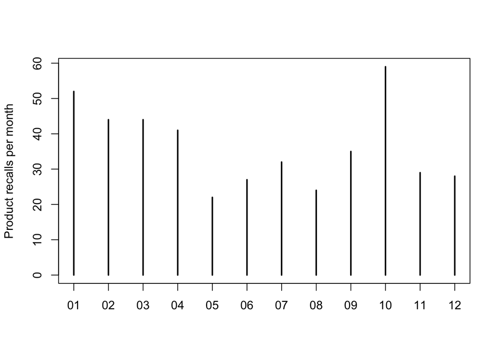

```r
plot(table(format(dataset$date2, '%m')), ylab="Product recalls per month")
```